# ETM 527 HW6

## Morgan Mahon

```python
# Setup
import pandas as pd
import matplotlib.pyplot as plt
import seaborn as sns
from sklearn.model_selection import train_test_split
from sklearn.linear_model import LogisticRegression
from sklearn.metrics import confusion_matrix
from sklearn.preprocessing import StandardScaler
from sklearn.neural_network import MLPRegressor
from sklearn.metrics import mean_squared_error
from sklearn.preprocessing import MinMaxScaler
```

## 10.2 Identifying Good System Administrators.

A management consultant is studying the roles played by experience and training in a system administrator’s ability to complete a set of tasks in a specified amount of time. In particular, she is interested in discriminating between administrators who are able to complete given tasks within a specified time and those who are not. Data are collected on the performance of 75 randomly selected administrators. They are stored in the file SystemAdministrators.csv.

The variable Experience measures months of full-time system administrator experience, while Training measures the number of relevant training credits. The outcome variable Completed is either Yes or No, according to whether or not the administrator completed the tasks.

```python
# Loading Data
Admin_df = pd.read_csv('SystemAdministrators.csv')
Admin_df.head()
```

|  | Experience | Training | Completed task |
| --- | --- | --- | --- |
| 0 | 10.9 | 4 | Yes |
| 1 | 9.9 | 4 | Yes |
| 2 | 10.4 | 6 | Yes |
| 3 | 13.7 | 6 | Yes |
| 4 | 9.4 | 8 | Yes |

#### a. Create a scatter plot of Experience vs. Training using color or symbol to distinguish programmers who completed the task from those who did not complete it. Which predictor(s) appear(s) potentially useful for classifying task completion?

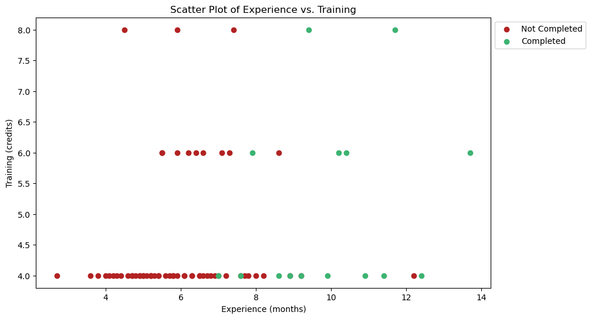

```python
plt.figure(figsize=(10, 6))

#Plot points for those who did *not* complete tasks
plt.scatter(
    Admin_df.loc[Admin_df['Completed task']=="No", 'Experience'],
    Admin_df.loc[Admin_df['Completed task']=="No", 'Training'],
    color='firebrick',
    label='Not Completed'
)

#Plot points for those who *did* complete tasks
plt.scatter(
    Admin_df.loc[Admin_df['Completed task']=="Yes", 'Experience'],
    Admin_df.loc[Admin_df['Completed task']=="Yes", 'Training'],
    color='mediumseagreen',
    label='Completed'
)

plt.xlabel('Experience (months)')
plt.ylabel('Training (credits)')
plt.title('Scatter Plot of Experience vs. Training')
plt.legend(bbox_to_anchor=(1, 1), loc='upper left')

plt.show()
```

> Based on the chart above, experience appears to be more useful for predicting task completion. This is because there is a more clear delineation between completed on teh right side and not completed tasks on the left side of around 8months experience. Alternatively, there appears to be a pretty even mix of both completion statuses for each level of training.

#### b. Run a logistic regression model with both predictors using the entire dataset as training data. Among those who completed the task, what is the percentage of programmers incorrectly classified as failing to complete the task?

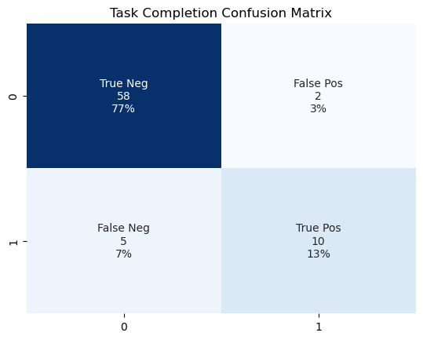

```python
#Set feature and targets
X = Admin_df[['Experience', 'Training']]
y = Admin_df['Completed task']

#Fit model on entire dataset
model = LogisticRegression()
model.fit(X,y)
y_pred = model.predict(X)

conf_matrix = confusion_matrix(y,y_pred)
group_names = ['True Neg', 'False Pos', 'False Neg', 'True Pos']
group_counts = ["{0:0.0f}".format(value) for value in conf_matrix.flatten()]
group_percentages = ["{0:.0%}".format(value) for value in conf_matrix.flatten()/np.sum(conf_matrix)]

labels = [f"{v1}\n{v2}\n{v3}" for v1, v2, v3 in zip(group_names, group_counts, group_percentages)]
labels = np.asarray(labels).reshape(2,2)


sns.heatmap(conf_matrix, annot=labels, fmt='', cmap='Blues', cbar=False)
plt.title('Task Completion Confusion Matrix')
plt.show()
```

> As shown in the above confusion matrix, out of all programmers 7% were incorrectly prediced to have not completed the task. Within just those programmers who did actually complete tasks (FN + TP = 15), the percentage of false negatives was around 33%.

#### c. To decrease the percentage in part (b), should the cutoff probability be increased or decreased?

> The probability cutoff should be reduced in order to decrease the number of negatives predicted. This will likely result in a greater proportion of false positives however, but that may be prefereable depending on the business use-case.

#### d. How much experience must be accumulated by a programmer with 4 years of training before his or her estimated probability of completing the task exceeds 0.5?

```python
# Probability = 1 / ( 1 + e^(β0 + β1*x1 + β2*x2 + ··· +βq*xq))
# log(p/(1-p))= β0 + β1*x1 + β2*x2

# Find the intercept + coefficients
intercept = model.intercept_[0]
coef_experience = model.coef_[0][0]
coef_training = model.coef_[0][1]

# Solve the equation where P(Y=1) = 0.5
# log(1) = β0 + β1*x1 + β2*x2
#  β2*x2 = -β0 - β1*x1
#  x2 = -β0 - β1*x1 / β2

Experience = (-intercept - coef_training*4) / coef_experience
Experience_round = round(Experience,2)
print(f"Experience must be greater than {Experience_round} months.")
```

```
Experience must be greater than 9.17 months.
```

> Solving the initial regression function for Training results in the following equation: x2 = -β0 - β1*x1 / β2. Once calculated, the estimated experience needed for probability of a task to exceed 0.5 is roughly 9 months. THis aligns with where we see a visual break between complete and not complete tasks in the scatterplot created in part a.

## 11.3 Car Sales.

Consider the data on used cars (ToyotaCorolla.csv) with 1436 records and details on 38 attributes, including Price, Age, KM, HP, and other specifications. The goal is to predict the price of a used Toyota Corolla based on its specifications.

```python
# Loading Data
Toyota_df = pd.read_csv('ToyotaCorolla.csv')
Toyota_df.head().transpose()
```

|  | 0 | 1 | 2 | 3 | 4 |
| --- | --- | --- | --- | --- | --- |
| Id | 1 | 2 | 3 | 4 | 5 |
| Model | TOYOTA Corolla 2.0 D4D HATCHB TERRA 2/3-Doors | TOYOTA Corolla 2.0 D4D HATCHB TERRA 2/3-Doors | ?TOYOTA Corolla 2.0 D4D HATCHB TERRA 2/3-Doors | TOYOTA Corolla 2.0 D4D HATCHB TERRA 2/3-Doors | TOYOTA Corolla 2.0 D4D HATCHB SOL 2/3-Doors |
| Price | 13500 | 13750 | 13950 | 14950 | 13750 |
| Age_08_04 | 23 | 23 | 24 | 26 | 30 |
| Mfg_Month | 10 | 10 | 9 | 7 | 3 |
| Mfg_Year | 2002 | 2002 | 2002 | 2002 | 2002 |
| KM | 46986 | 72937 | 41711 | 48000 | 38500 |
| Fuel_Type | Diesel | Diesel | Diesel | Diesel | Diesel |
| HP | 90 | 90 | 90 | 90 | 90 |
| Met_Color | 1 | 1 | 1 | 0 | 0 |
| Automatic | 0 | 0 | 0 | 0 | 0 |
| cc | 2000 | 2000 | 2000 | 2000 | 2000 |
| Doors | 3 | 3 | 3 | 3 | 3 |
| Cylinders | 4 | 4 | 4 | 4 | 4 |
| Gears | 5 | 5 | 5 | 5 | 5 |
| Quarterly_Tax | 210 | 210 | 210 | 210 | 210 |
| Weight | 1165 | 1165 | 1165 | 1165 | 1170 |
| Mfr_Guarantee | 0 | 0 | 1 | 1 | 1 |
| BOVAG_Guarantee | 1 | 1 | 1 | 1 | 1 |
| Guarantee_Period | 3 | 3 | 3 | 3 | 3 |
| ABS | 1 | 1 | 1 | 1 | 1 |
| Airbag_1 | 1 | 1 | 1 | 1 | 1 |
| Airbag_2 | 1 | 1 | 1 | 1 | 1 |
| Airco | 0 | 1 | 0 | 0 | 1 |
| Automatic_airco | 0 | 0 | 0 | 0 | 0 |
| Boardcomputer | 1 | 1 | 1 | 1 | 1 |
| CD_Player | 0 | 1 | 0 | 0 | 0 |
| Central_Lock | 1 | 1 | 0 | 0 | 1 |
| Powered_Windows | 1 | 0 | 0 | 0 | 1 |
| Power_Steering | 1 | 1 | 1 | 1 | 1 |
| Radio | 0 | 0 | 0 | 0 | 0 |
| Mistlamps | 0 | 0 | 0 | 0 | 1 |
| Sport_Model | 0 | 0 | 0 | 0 | 0 |
| Backseat_Divider | 1 | 1 | 1 | 1 | 1 |
| Metallic_Rim | 0 | 0 | 0 | 0 | 0 |
| Radio_cassette | 0 | 0 | 0 | 0 | 0 |
| Tow_Bar | 0 | 0 | 0 | 0 | 0 |

#### a. Fit a neural network model to the data. Use a single hidden layer with 2 nodes.

- Use predictors Age_08_04, KM, Fuel_Type, HP, Automatic, Doors, Quarterly_Tax, Mfr_Guarantee, Guarantee_Period, Airco, Automatic_airco, CD_Player, Powered_Windows, Sport_Model, and Tow_Bar.

```python
selected_predictors = ['Age_08_04', 'KM', 'Fuel_Type', 'HP', 'Automatic', 'Doors', 'Quarterly_Tax',
                       'Mfr_Guarantee', 'Guarantee_Period', 'Airco', 'Automatic_airco', 'CD_Player',
                       'Powered_Windows', 'Sport_Model', 'Tow_Bar', 'Price']

Toyota_df = Toyota_df[selected_predictors]

X = Toyota_df.drop('Price', axis=1)
y = Toyota_df['Price']
```

- Remember to first scale the numerical predictor and outcome variables to a 0–1 scale (use function preprocess() with method = “range”—see Chapter 7) and convert categorical predictors to dummies.

```python
# Determining Num & Cat variables
numerical_cols = X.select_dtypes(include=['float64', 'int64']).columns
categorical_cols = X.select_dtypes(include=['object']).columns
print(numerical_cols)
print(categorical_cols)
```

```
Index(['Age_08_04', 'KM', 'HP', 'Automatic', 'Doors', 'Quarterly_Tax',
       'Mfr_Guarantee', 'Guarantee_Period', 'Airco', 'Automatic_airco',
       'CD_Player', 'Powered_Windows', 'Sport_Model', 'Tow_Bar'],
      dtype='object')
Index(['Fuel_Type'], dtype='object')
```

```python
# Get dummies for Fuel Type
Toyota_df_dummies = pd.get_dummies(Toyota_df['Fuel_Type'], prefix='Fuel_Type')
Toyota_df = pd.concat([Toyota_df, Toyota_df_dummies], axis=1)
Toyota_df = Toyota_df.drop('Fuel_Type', axis=1)
Toyota_df.head().transpose()
```

|  | 0 | 1 | 2 | 3 | 4 |
| --- | --- | --- | --- | --- | --- |
| Age_08_04 | 23 | 23 | 24 | 26 | 30 |
| KM | 46986 | 72937 | 41711 | 48000 | 38500 |
| HP | 90 | 90 | 90 | 90 | 90 |
| Automatic | 0 | 0 | 0 | 0 | 0 |
| Doors | 3 | 3 | 3 | 3 | 3 |
| Quarterly_Tax | 210 | 210 | 210 | 210 | 210 |
| Mfr_Guarantee | 0 | 0 | 1 | 1 | 1 |
| Guarantee_Period | 3 | 3 | 3 | 3 | 3 |
| Airco | 0 | 1 | 0 | 0 | 1 |
| Automatic_airco | 0 | 0 | 0 | 0 | 0 |
| CD_Player | 0 | 1 | 0 | 0 | 0 |
| Powered_Windows | 1 | 0 | 0 | 0 | 1 |
| Sport_Model | 0 | 0 | 0 | 0 | 0 |
| Tow_Bar | 0 | 0 | 0 | 0 | 0 |
| Price | 13500 | 13750 | 13950 | 14950 | 13750 |
| Fuel_Type_CNG | False | False | False | False | False |
| Fuel_Type_Diesel | True | True | True | True | True |
| Fuel_Type_Petrol | False | False | False | False | False |

```python
# Scaling numerical input columns

# Dropping columns already in binary scale
columns_to_drop = ['Automatic', 'Mfr_Guarantee', 'Airco', 'Automatic_airco',
                   'CD_Player', 'Powered_Windows', 'Sport_Model', 'Tow_Bar']
numerical_cols = numerical_cols.difference(columns_to_drop)

input_data = Toyota_df[numerical_cols]
outcome_variable = Toyota_df['Price']

scaler = MinMaxScaler()
input_data_scaled = scaler.fit_transform(input_data)

# Scaling outcome column
outcome_variable_2d = outcome_variable.values.reshape(-1, 1)
output_data_scaled = scaler.fit_transform(outcome_variable_2d)
```

- Record the RMS error for the training data and the validation data. Repeat the process, changing the number of hidden layers and nodes to {single layer with 5 nodes}, {two layers, 5 nodes in each layer}.

#### Single hidden layer with 2 nodes

```python
# Split into training and validation sets
X_train, X_val, y_train, y_val = train_test_split(input_data_scaled, output_data_scaled, test_size=0.2, random_state=42)

# Fit a neural network model with a single hidden layer and 2 nodes
model = MLPRegressor(hidden_layer_sizes=(2,), max_iter=1000, random_state=17)
model.fit(X_train, y_train.ravel())

# Predictions on training and validation sets
y_train_pred = scaler.inverse_transform(model.predict(X_train).reshape(-1, 1))
y_val_pred = scaler.inverse_transform(model.predict(X_val).reshape(-1, 1))

# RMS error for training and validation sets
rms_error_train = round(mean_squared_error(y_train, y_train_pred, squared=False),2)
rms_error_val = round(mean_squared_error(y_val, y_val_pred, squared=False),2)

print(f"RMS Error (Training - Single Layer, 2 Nodes): {rms_error_train}")
print(f"RMS Error (Validation - Single Layer, 2 Nodes): {rms_error_val}")
```

```
RMS Error (Training - Single Layer, 2 Nodes): 10846.53
RMS Error (Validation - Single Layer, 2 Nodes): 10880.62
```

#### Single layer with 5 nodes

```python
# Fit a neural network model with a single hidden layer and 5 nodes
model_single_layer_5_nodes = MLPRegressor(hidden_layer_sizes=(5,), max_iter=1000, random_state=42)
model_single_layer_5_nodes.fit(X_train, y_train.ravel())

# Make predictions on training and validation sets
y_train_pred_single_layer_5_nodes = scaler.inverse_transform(model_single_layer_5_nodes.predict(X_train).reshape(-1, 1))
y_val_pred_single_layer_5_nodes = scaler.inverse_transform(model_single_layer_5_nodes.predict(X_val).reshape(-1, 1))

# Calculate RMS error for training and validation sets
rms_error_train_single_layer_5_nodes = round(mean_squared_error(y_train, y_train_pred_single_layer_5_nodes, squared=False),2)
rms_error_val_single_layer_5_nodes = round(mean_squared_error(y_val, y_val_pred_single_layer_5_nodes, squared=False),2)

print(f"RMS Error (Training - Single Layer, 5 Nodes): {rms_error_train_single_layer_5_nodes}")
print(f"RMS Error (Validation - Single Layer, 5 Nodes): {rms_error_val_single_layer_5_nodes}")
```

```
RMS Error (Training - Single Layer, 5 Nodes): 10829.73
RMS Error (Validation - Single Layer, 5 Nodes): 10623.53
```

#### Two layers, 5 nodes in each layer

```python
# Fit a neural network model with two hidden layers, each having 5 nodes
model_two_layers_5_nodes = MLPRegressor(hidden_layer_sizes=(5, 5), max_iter=1000, random_state=42)
model_two_layers_5_nodes.fit(X_train, y_train.ravel())

# Make predictions on training and validation sets
y_train_pred_two_layers_5_nodes = scaler.inverse_transform(model_two_layers_5_nodes.predict(X_train).reshape(-1, 1))
y_val_pred_two_layers_5_nodes = scaler.inverse_transform(model_two_layers_5_nodes.predict(X_val).reshape(-1, 1))

# Calculate RMS error for training and validation sets
rms_error_train_two_layers_5_nodes = round(mean_squared_error(y_train, y_train_pred_two_layers_5_nodes, squared=False),2)
rms_error_val_two_layers_5_nodes = round(mean_squared_error(y_val, y_val_pred_two_layers_5_nodes, squared=False),2)

print(f"RMS Error (Training - Two Layers, 5 Nodes Each): {rms_error_train_two_layers_5_nodes}")
print(f"RMS Error (Validation - Two Layers, 5 Nodes Each): {rms_error_val_two_layers_5_nodes}")
```

```
RMS Error (Training - Two Layers, 5 Nodes Each): 11325.45
RMS Error (Validation - Two Layers, 5 Nodes Each): 11244.18
```

1. i. What happens to the RMS error for the training data as the number of layers and nodes increases?

> As the nodes are increased, the RMS Error decreases, indicating that the model better fits the data. It fits the training data better as it becomes more complex adn tehrefore better and capturing small details of the training data. As the number of layers increases however, the RMS Error also increases, indicating that the fit becomes worse.
1. ii. What happens to the RMS error for the validation data?

> The same trend was observed with the validation data as with the training data. There was one main difference noted for the second model, with 5 nodes instead of 2, where the RMSE fell quite a bit lower on teh validation data than the training data.
1. iii. Comment on the appropriate number of layers and nodes for this application.

> Given that the lowest RMSE for both the training and validation sets was found on the net with one layer and 5 nodes, this appears to be the appropriate combination for this analysis.